# Proper Orthogonal Decomposition based reduced order modeling for the heat equation

Finally, we come to the time-stepping loop itself. For this we create the function $u$, which represents the solution at the current time step, i.e. $u := u_{n+1}$. In the loop itself, we than compute $t_{n+1}$ as $t_n + \Delta t$. Afterwards we solve the variational problem $a(u_{n+1}, v) = L(v)$. Having computed the solution, we can verify its correctness, since we know that the analytical solution is given as $$ u(t,x,y) = \exp(-2\pi^2 t)\sin(\pi x)\sin(\pi y). $$ A common choice is to ensure that the $L^2((0,T), L^2(\Omega))$ norm of $u - u_h$ converges to 0 and the convergence rate should depend on the type of spatio-temporal discretization. However, in this tutorial, we go a different route and want to verify that $J(u(t,\cdot, \cdot )) - J(u_h(t,\cdot, \cdot ))$ converges to $0$ for $\Delta t, h \rightarrow 0$, where $J(\cdot)$ is a quantity of interest that we are monitoring. For our model problem, we decide that we are interested in evaluating the solution at the center of the domain, i.e. $$ J(\tilde{u}(t, \cdot, \cdot)) := \tilde{u}\left(t, \frac{1}{2}, \frac{1}{2}\right) $$ and we have for the analytical solution $u$ that $$ J(u(t, \cdot, \cdot)) = u\left(t, \frac{1}{2}, \frac{1}{2}\right) = \exp(-2\pi^2 t)\sin\left(\frac{\pi}{2}\right)\sin\left(\frac{\pi}{2}\right) = \exp(-2\pi^2 t). $$ Having compared the difference between the analytical solution $u$ and its FEM approximation $u_h$ in the goal functional $J(\cdot)$, we plot the FEM solution and finally update $u_n$ for the computations in the next time step.

```
Calling FFC just-in-time (JIT) compiler, this may take some time.
Calling FFC just-in-time (JIT) compiler, this may take some time.
Calling FFC just-in-time (JIT) compiler, this may take some time.
Calling FFC just-in-time (JIT) compiler, this may take some time.
t = 0.01:
  u_h(0.5,0.5) = 0.819327
  u(0.5,0.5)   = 0.820869
```

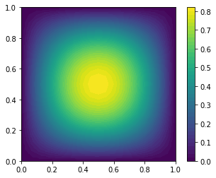

```
t = 0.02:
  u_h(0.5,0.5) = 0.671299
  u(0.5,0.5)   = 0.673825
```

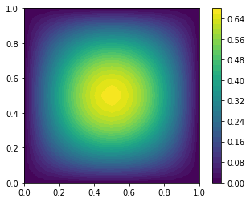

```
t = 0.03:
  u_h(0.5,0.5) = 0.550015
  u(0.5,0.5)   = 0.553122
```

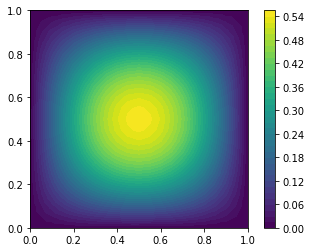

```
t = 0.04:
  u_h(0.5,0.5) = 0.450645
  u(0.5,0.5)   = 0.454041
```

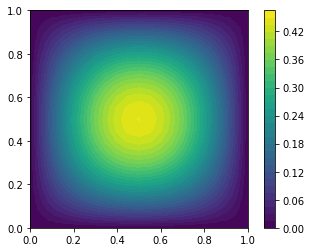

```
t = 0.05:
  u_h(0.5,0.5) = 0.369228
  u(0.5,0.5)   = 0.372708
```

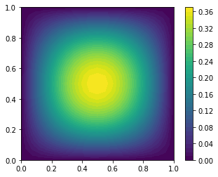

```
t = 0.06:
  u_h(0.5,0.5) = 0.302519
  u(0.5,0.5)   = 0.305944
```

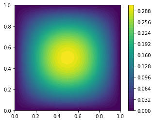

```
t = 0.07:
  u_h(0.5,0.5) = 0.247864
  u(0.5,0.5)   = 0.25114
```

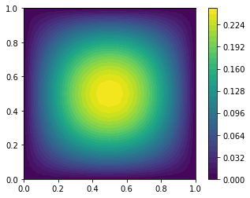

```
t = 0.08:
  u_h(0.5,0.5) = 0.203082
  u(0.5,0.5)   = 0.206153
```

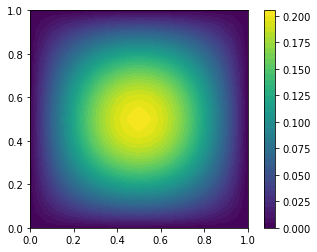

```
t = 0.09:
  u_h(0.5,0.5) = 0.166391
  u(0.5,0.5)   = 0.169225
```

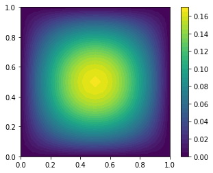

```
t = 0.1:
  u_h(0.5,0.5) = 0.13633
  u(0.5,0.5)   = 0.138911
```

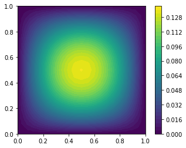

```
t = 0.11:
  u_h(0.5,0.5) = 0.111699
  u(0.5,0.5)   = 0.114028
```

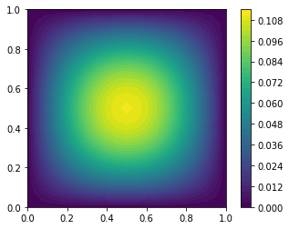

```
t = 0.12:
  u_h(0.5,0.5) = 0.091518
  u(0.5,0.5)   = 0.093602
```

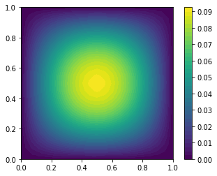

```
t = 0.13:
  u_h(0.5,0.5) = 0.074984
  u(0.5,0.5)   = 0.076835
```

[38 more figures not shown]

```python
# Time-stepping
u = Function(V) # u = u_{n+1}: current solution

while(t+Δt <= T+1e-8):
    # Update current time
    t += Δt

    # Compute solution
    solve(a == L, u, bc)

    # Print results for quantity of interest J(u) := u(0.5,0.5)
    print(f"t = {round(t,4)}:")
    print(f"  u_h(0.5,0.5) = {round(u(Point(0.5, 0.5)),6)}")
    print(f"  u(0.5,0.5)   = {round(math.exp(-2 * math.pi**2 * t),6)}")

    # Plot solution
    c = plot(u)
    plt.colorbar(c)
    plt.show()

    # Update previous solution
    u_n.assign(u)
```

We observe that our FEM solution resembles a peak centered at $\left( \frac{1}{2}, \frac{1}{2} \right)$ whose amplitude decreases over time. This is what we expected, knowing that the analytical solution reads $$ u(t,x,y) = \exp(-2\pi^2 t)\sin(\pi x)\sin(\pi y). $$ Morever, we see that evaluating the analytical solution and its FEM approximation in the quantity of interest $J(\cdot)$ yields similar results, even though the relative error is at times close to $10 \%$, since we use a coarse spatial grid and large time step size.

### Exercises

1. *Verify that $J(u) - J(u_h) \rightarrow 0$ for $\Delta t, h \rightarrow 0$:* Try different values for $\Delta t$ and $n_x$, $n_y$. What is the smallest relative error in $J(\cdot)$ that you can get experimentally?
2. *Try out different values for $\theta$:* How does the quality of your FEM results depend on the choice of $\theta$? Try out $\theta = 0, \theta = 1$ and $\theta = \frac{1}{2}$. Interpret your results and compare your observations with the literature on numerical methods for Ordinary Differential Equations, in particular the literature on the forward/backward Euler scheme and the Crank-Nicholson scheme.

## The matrix assembly / deal.II way of solving the heat equation

In this section, we will make the first step necessary for Proper Orthogonality Decomposition based Reduced Order Modeling. We will tackle the same model problem as before, but instead of solving the variational formulation in UFL form, we will assembly the linear equation system explicitly since this will also be required for creating the reduced order model. Implementing the assembly of the linear system is the cornerstone of many FEM programs, e.g. the [deal.II library](https://www.dealii.org/) . Additionally, we store each of the snapshots of the FEM computation in the snapshot matrix $Y$, which we will need for finding the POD basis that will replace the large dimensional FEM basis.

### Code

First, we specify the parameters of the time discretization:

```python
# start time
t = 0.
# end time
T = 0.5
# time step size
Δt = 0.01
# one-step theta
θ = 0.5
```

Next, we create a triangulation of the domain $\Omega = (0,1) \times (0,1)$.

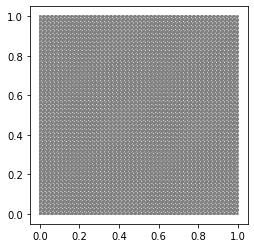

```python
nx = ny = 50
mesh = UnitSquareMesh(nx, ny)
# visualize the triangulation
plot(mesh)
plt.show()
```

Then, we define on this mesh the space of bilinear finite elements and create homogeneous Dirichlet boundary conditions on the entire boundary.

```python
V = FunctionSpace(mesh, 'P', 1)
bc = DirichletBC(V, Constant(0.), lambda _, on_boundary: on_boundary)
```

We now define the expression for the initial condition as $u_0$ and interpolate it in the function space $V$. Here we will use the variable $u_n$ as the solution from the last timestep.

```python
# initial condition
u_0 = Expression('sin(pi*x[0])*sin(pi*x[1])', degree=2, pi=math.pi)
# u_n: solution from last time step
u_n = interpolate(u_0, V)
```

Now, we are at the point where things get a little different than in the previous section, where we used UFL to define the variational formulation (1) and (2). In the following, we will use the corresponding linear equation system. For a more detailed explanation of how to get from the variational formulation to a linear equation system, please take a look at my [tutorial on the finite element method](http://julianroth.org/documentation/fem/) .

Mainly to get the linear system, we need to use the fact that we know the finite dimensional basis $\lbrace \varphi_i \rbrace_{i=1}^m$ of $V$. Since $u_{n+1}$ and $u_n$ are functions from $V$, they can be expressed as a linear combination of this basis, i.e. $$ u_{n+1}(x,y) := \sum_{i=1}^m U^{n+1}_i \cdot \varphi_i(x,y), \\ u_{n}(x,y) := \sum_{i=1}^m U^{n}_i \cdot \varphi_i(x,y). $$ Plugging this into the bilinear form (1) and the right hand side (2) of the variational formulation, we only need to be able to assemble the mass matrix $M \in \mathbb{R}^{m \times m}$, which is defined by $$ M_{ij} = \int_\Omega \varphi_i \cdot \varphi_j\ \mathrm{d}(x,y), $$ and we need to assemble the Laplacian/stiffness matrix $K \in \mathbb{R}^{m \times m}$, which is defined by $$ K_{ij} = \int_\Omega \nabla_x \varphi_i \cdot \nabla_x \varphi_j\ \mathrm{d}(x,y). $$

Using these two matrices, the linear equation system reads: \ Find $\vec{U}^{n+1} \in \mathbb{R}^m$ such that $$ [M + \theta \cdot \Delta t \cdot K]\vec{U}^{n+1} = [M - (1-\theta) \cdot \Delta t \cdot K]\vec{U}^n. $$

Thus, we start off by assembling the mass matrix $M$ and the Laplace matrix $K$.

```python
# Define variational problem
u = TrialFunction(V)
v = TestFunction(V)

# mass matrix
M = assemble(u*v*dx)

# Laplace matrix
K = assemble(dot(grad(u), grad(v))*dx)
```

```
Calling FFC just-in-time (JIT) compiler, this may take some time.
Calling FFC just-in-time (JIT) compiler, this may take some time.
Calling FFC just-in-time (JIT) compiler, this may take some time.
Calling FFC just-in-time (JIT) compiler, this may take some time.
Calling FFC just-in-time (JIT) compiler, this may take some time.
```

With the help of the mass matrix $M$ and the Laplace matrix $K$, we can now define the system matrix $$ A^{n+1} := M + \theta \cdot \Delta t \cdot K, $$ and the right hand side matrix $$ A^n := M - (1-\theta) \cdot \Delta t \cdot K. $$ Later, we will then only need to solve the linear system $$ A^{n+1}\vec{U}^{n+1} = A^n\vec{U}^n. $$

```python
# system matrix
system_matrix = M + θ * Δt * K

# right hand side matrix
rhs_matrix = M - (1. - θ) * Δt * K
```

Next, we create a snapshot matrix $Y \in \mathbb{R}^{m \times n}$, where $m$ is the size of the FEM basis and $n$ is the number of snapshots of the FEM solution. We add the initial condition as the first column of this matrix and afterwards in the time-stepping scheme fill the remaining columns.

```python
# number of snapshots
n = int(math.ceil((T-t)/Δt))+1

# number of degrees of freedom
m = V.dim()

# snapshot matrix
Y = np.zeros((m, n))

# store initial condition in snapshot matrix
Y[:, 0] = u_n.vector()
```

Finally, we come to the time-stepping loop itself. For this we create the function $u$, which represents the solution at the current time step, i.e. $u := u_{n+1}$. In the loop itself, we then compute $t_{n+1}$ as $t_n + \Delta t$. Afterwards we solve the linear system $$ A^{n+1}\vec{U}^{n+1} = A^n\vec{U}^n, $$ which corresponds to the variational problem $a(u_{n+1}, v) = L(v)$. Having computed the solution, we can verify its correctness, since we know that the analytical solution is given as $$ u(t,x,y) = \exp(-2\pi^2 t)\sin(\pi x)\sin(\pi y). $$ We want to verify that $J(u(t,\cdot, \cdot )) - J(u_h(t,\cdot, \cdot ))$ converges to $0$ for $\Delta t, h \rightarrow 0$, where $J(\cdot)$ is a quantity of interest that we are monitoring. For our model problem, we decide that we are interested in evaluating the solution at the center of the domain, i.e. $$ J(\tilde{u}(t, \cdot, \cdot)) := \tilde{u}\left(t, \frac{1}{2}, \frac{1}{2}\right) $$ and we have for the analytical solution $u$ that $$ J(u(t, \cdot, \cdot)) = \exp(-2\pi^2 t). $$ Having compared the difference between the analytical solution $u$ and its FEM approximation $u_h$ in the goal functional $J(\cdot)$, we plot the FEM solution, store the solution in the snapshot matrix and finally update $u_n$ for the computations in the next time step.

```
t = 0.01:
  u_h(0.5,0.5) = 0.820178
  u(0.5,0.5)   = 0.820869
```

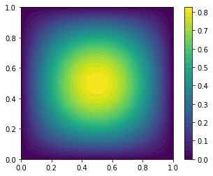

```
t = 0.02:
  u_h(0.5,0.5) = 0.672692
  u(0.5,0.5)   = 0.673825
```

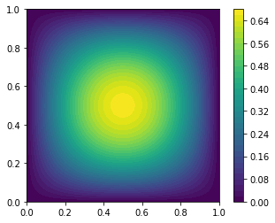

```
t = 0.03:
  u_h(0.5,0.5) = 0.551728
  u(0.5,0.5)   = 0.553122
```

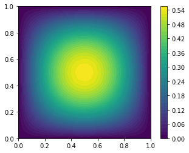

```
t = 0.04:
  u_h(0.5,0.5) = 0.452515
  u(0.5,0.5)   = 0.454041
```

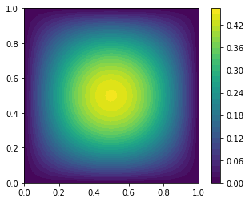

```
t = 0.05:
  u_h(0.5,0.5) = 0.371143
  u(0.5,0.5)   = 0.372708
```

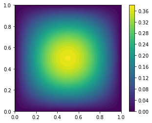

```
t = 0.06:
  u_h(0.5,0.5) = 0.304403
  u(0.5,0.5)   = 0.305944
```

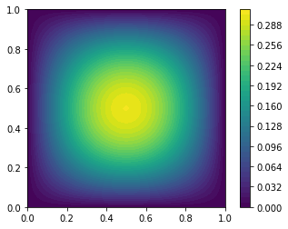

```
t = 0.07:
  u_h(0.5,0.5) = 0.249665
  u(0.5,0.5)   = 0.25114
```

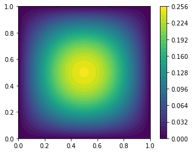

```
t = 0.08:
  u_h(0.5,0.5) = 0.20477
  u(0.5,0.5)   = 0.206153
```

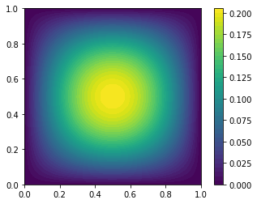

```
t = 0.09:
  u_h(0.5,0.5) = 0.167948
  u(0.5,0.5)   = 0.169225
```

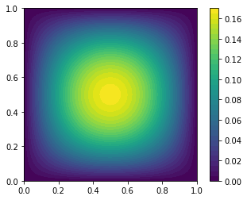

```
t = 0.1:
  u_h(0.5,0.5) = 0.137747
  u(0.5,0.5)   = 0.138911
```

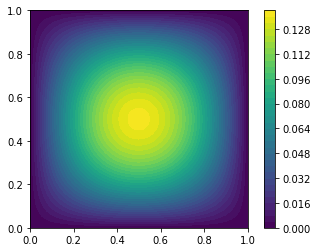

```
t = 0.11:
  u_h(0.5,0.5) = 0.112977
  u(0.5,0.5)   = 0.114028
```

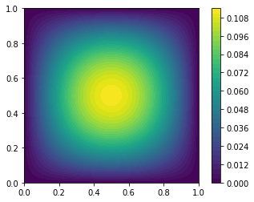

```
t = 0.12:
  u_h(0.5,0.5) = 0.092661
  u(0.5,0.5)   = 0.093602
```

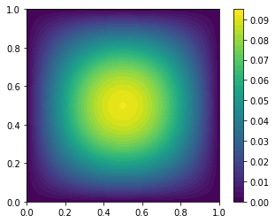

```
t = 0.13:
  u_h(0.5,0.5) = 0.075999
  u(0.5,0.5)   = 0.076835
```

[38 more figures not shown]

```python
# Time-stepping
u = Function(V) # u_{n+1}: current solution

n = 1
while(t+Δt <= T+1e-8):
    # Update current time
    t += Δt

    # Compute solution
    A = system_matrix
    # Compute RHS
    b = u_n.vector().copy()
    rhs_matrix.mult(u_n.vector(), b)
    # Apply boundary conditions
    bc.apply(A,b)
    # Solve linear system
    solve(A, u.vector(), b)

    # Print results
    print(f"t = {round(t,4)}:")
    print(f"  u_h(0.5,0.5) = {round(u(Point(0.5, 0.5)),6)}")
    print(f"  u(0.5,0.5)   = {round(math.exp(-2 * math.pi**2 * t),6)}")

    # Plot solution
    c = plot(u)
    plt.colorbar(c)
    plt.show()

    # Store solution in snapshot matrix
    Y[:, n] = u.vector()
    n += 1

    # Update previous solution
    u_n.assign(u)
```

## Reduced Order Modeling

We saw in the previous section that to solve the heat equation with finite elements we need to solve a linear equation system of size $m$, where $m$ denotes the number of degrees of freedom. For 3D problems, complex geometries or fine meshes the number of degrees of freedom can quickly become very large, which makes this linear system computationally expensive to solve. However, for many applications in industry it might be required that these simulations are (almost) real-time. Hence, in such scenarios reduced order models of size $r \ll m$ are being used. A popular approach for this is Proper Orthogonal Decomposition (POD) based reduced order modeling (ROM), where one tries to find a new basis from the snapshots of the high fidelity simulation and then carries out all remaining simulations in this low dimensional function space.

In the following, we will discuss the main aspects of POD-ROM, but for more details please check out my [master's thesis](https://julianroth.org/res/Master_Thesis_Julian_Roth.pdf) or [Prof. Volkwein's lecture notes](http://www.math.uni-konstanz.de/numerik/personen/volkwein/teaching/POD-Book.pdf).

### Compute Proper Orthogonal Decomposition (POD) basis

In the first part of reduced order modeling, we first need to find a new basis of size $r \ll m$, which preserves the majority of the information of the high fidelity simulation. To find this POD basis, we need to follow the steps:

1. assemble the correlation matrix
2. compute the eigenvalues/-vectors of the correlation matrix
3. determine the POD basis size $r$
4. caclulate the POD basis vectors from the eigenvalues/-vectors of the correlation matrix

**1. Assemble the correlation matrix** \ The correlation matrix is defined as $$ C := D^{\frac{1}{2}}Y^T W Y D^{\frac{1}{2}}, $$ where $Y$ is the snapshot matrix, $W$ is the weight matrix, which is usually either the mass matrix, i.e. $W = M$, or the Laplace matrix, i.e. $W = K$, and $D$ is a diagonal matrix containing the time quadrature weights. For our computations, we choose $W = M$ and due to a uniform time step size, we get with the trapezoidal rule for the integration of the time integral that $D \approx \frac{1}{\Delta t}I$. Here, $I$ stands for the identity matrix in $\mathbb{R}^{m \times m}$. With these simplifications, we get $$ C := \frac{1}{\Delta t} \cdot Y^T M Y. $$

```python
# assemble correlation matrix
correlation_matrix = (1. / Δt) * np.dot(np.dot(Y.T, M.array()),Y)
```

**2. Compute the eigenvalues/-vectors of the correlation matrix** \ Next, we compute the eigenvalues and eigenvectors of this correlation matrix. Since $M$ is symmetric, the correlation matrix is a real, symmetric matrix and thus only has real eigenvalues and eigenvectors. Additionally, we sort the eigenavalues in descending order, which we will need to determine the size of the POD basis.

```python
# compute eigenvalues of correlation matrix
eigen_values, eigen_vectors = np.linalg.eig(correlation_matrix)

# ignore the complex part of the eigen values and eigen vectors
eigen_values, eigen_vectors = eigen_values.astype('float64'), eigen_vectors.astype('float64')

# sort the eigenvalues in descending order
eigen_values, eigen_vectors = eigen_values[eigen_values.argsort()[::-1]], eigen_vectors[eigen_values.argsort()[::-1]]
```

To verify whether using a POD based reduced order model actually makes sense, we need to check whether the the eigenvalues of the correlation matrix decay sufficiently fast. If this is the case, then only a small number of POD modes will be sufficient to build a reduced order model. There are also PDEs for which this assumption is not satisfied, e.g. one-dimensional linear transport. For more information on this, please check out the book from Quarteroni and Rozza ["Reduced Order Methods for Modeling and Computation"](https://link.springer.com/chapter/10.1007/978-3-319-02090-7_9).

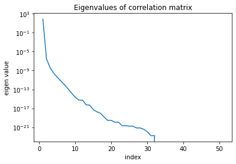

```python
plt.plot(range(1,min(n,m)+1), eigen_values)
plt.yscale("log")
plt.xlabel("index")
plt.ylabel("eigen value")
plt.title("Eigenvalues of correlation matrix")
plt.show()
```

We observe that the eigenvalues decay very rapidly and hence we expect to get a reduced order model with only a few POD basis vectors.

**3. Determine the POD basis size $r$** \

There is no formula for the optimal size for the POD basis. Instead, most of the POD literature uses a heuristic, which tries to preserve a certain amount of the energy of the snapshots. The energy of the high fidelity solution is $$ \sum_{i = 1}^n \lambda_i, $$ where $\lbrace \lambda_i \rbrace_{i = 1}^n$ denote the eigenvalues of the correlation matrix. If we take only the $r$ largest eigenvalues/-vectors of the correlation matrix, it can be shown that they have the energy $$ \sum_{i = 1}^r \lambda_i. $$ The heuristic from the literature is then to find the smallest $r \in \mathbb{N}$ such that the energy ratio $$ \frac{\sum_{i = 1}^r \lambda_i}{\sum_{i = 1}^n \lambda_i} $$ is larger than a user-defined threshold, e.g. $0.99$, $0.999$, ...

```python
# desired energy ratio
ENERGY_RATIO_THRESHOLD = 0.999

# determine number of POD basis vectors needed to preserve certain ratio of energy
r = np.sum([(eigen_values[:i].sum() / eigen_values.sum()) < ENERGY_RATIO_THRESHOLD for i in range(n)])
print(f"To preserve {ENERGY_RATIO_THRESHOLD} of information we need {r} POD vector(s). (result: {eigen_values[:r].sum() / eigen_values.sum()} information).")
```

```
To preserve 0.999 of information we need 1 POD vector(s). (result: 0.9999999961606815 information).
```

**4. Caclulate the POD basis vectors from the eigenvalues/-vectors of the correlation matrix** \ Finally, we find that the POD basis is given by $$ \vec\psi_i := \frac{YD^{\frac{1}{2}}\vec{w}_i}{\sqrt{\lambda_i}} \qquad \forall 1 \leq i \leq r, $$ where $\lbrace \lambda_i \rbrace_{i = 1}^n$ denote the eigenvalues and $\lbrace \vec{w}_i \rbrace_{i = 1}^n$ denote the eigenvectors of the correlation matrix. Using $D \approx \frac{1}{\Delta t}I$, we then get that $$ \vec\psi_i := \sqrt{\frac{1}{\Delta t}}\frac{Y\vec{w}_i}{\sqrt{\lambda_i}} \qquad \forall 1 \leq i \leq r. $$

```python
# compute POD basis vectors
pod_basis = np.sqrt(1. / Δt) * np.dot(Y, eigen_vectors[:,:r])  / np.diag(np.sqrt(eigen_values[:r]))
```

Having computed our POD basis, we can now visualize the individual POD vectors.

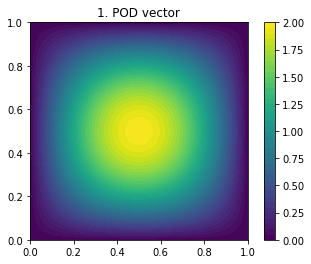

```python
# Plot solution
w = Function(V)
for i in range(r):
  w.vector()[:] = pod_basis[:, i]
  c = plot(w)
  plt.colorbar(c)
  plt.title(f"{i+1}. POD vector")
  plt.show()
```

Since $r = 1$, we have only one POD vector. This was also to be expected, since the analytical solution is given by $$ u(t,x,y) = \exp(-2\pi^2 t)\sin(\pi x)\sin(\pi y). $$ and thus we only expected one POD mode in the first place. Furthermore, we see that the POD mode resembles a scaled version of $$ \sin(\pi x)\sin(\pi y), $$ which is what we hoped for.

### Compute reduced matrices

For the reduced order modeling, we now need to transform all our matrices and vectors from the FEM space to the ROM space. For this we write all our POD basis vectors in a matrix $$ \Psi := \begin{bmatrix} \vec\psi_1, \cdots, \vec\psi_r \end{bmatrix} \in \mathbb{R}^{m \times r}. $$

Let us first discuss how we can transform a general FEM matrix $A_h \in \mathbb{R}^{m \times m}$, where the subscript $h$ indicates that this is a FEM matrix. To get its reduced counterpart, we need to perform a change of basis by $$ A_r := \underbrace{\Psi^T}_{\in \mathbb{R}^{r \times m}} \underbrace{A_h}_{\in \mathbb{R}^{m \times m}} \underbrace{\Psi}_{\in \mathbb{R}^{m \times r}} \in \mathbb{R}^{r \times r}. $$ Here the subscript $r$ indicates that this is a ROM matrix. \ Similarly, for a general FEM vector $\vec{v}_h \in \mathbb{R}^m$, we get its reduced counterpart by the change of basis $$ \vec{v}_r := \underbrace{\Psi^T}_{\in \mathbb{R}^{r \times m}} \underbrace{\vec{v}_h}_{\in \mathbb{R}^{m}} \in \mathbb{R}^{r}. $$

We now apply this change of basis to the system matrix $A^{n+1} \in \mathbb{R}^{m \times m}$ and the right hand side matrix $A^{n} \in \mathbb{R}^{m \times m}$. We now need to solve the reduced linear equation system: \ Find $\vec{U}_r^{n+1} \in \mathbb{R}^r$ such that $$ \underbrace{A^{n+1}_r}_{\in \mathbb{R}^{r \times r}}\vec{U}_r^{n+1} = \underbrace{A^n_r}_{\in \mathbb{R}^{r \times r}}\vec{U}_r^n. $$

```python
# change from the FOM to the POD basis
reduced_system_matrix = np.dot(np.dot(pod_basis.T, system_matrix.array()), pod_basis)
reduced_rhs_matrix    = np.dot(np.dot(pod_basis.T,    rhs_matrix.array()), pod_basis)
```